# Logistic Regression on Baxter colorectal cancer dataset

### Backgorund

Colorectal cancer is one of the leading cause of death among cancers in the United States. Early diagnosis highly increases the chance of survival. However the current diagnostic methods are expensive and invasive. As a less invasive tool, numerous studies have used gut microbiome composition to predict disease progression. Each study uses different machine learning pipelines to classify disease progression which negatively impacts the reproducibility, robustness and actionability of this tool.

### Goal of this project

We want to evaluate the classification success of different machine learning methods. We also want to discuss the reproducibility, robustness, actionability, interpretibility and susceptibility to overfitting of each method.

### Methods

We sequenced the 16S rRNA genes from the stool samples of 292 patients, 120 with colorectal cancer and 172 with healthy colons. We used the relative abundances of the bacterial populations within each sample to develop a L2-regularized logistic regression, SVM(linear), SVM(non-linear), decision tree, random forest, XGBoost and feed forward neural net(1 hidden layer) classification models that detects colonic lesions using the relative abundance of gut microbiota.

### Results

So far, I have used L2 logistic, Random Forest, PyTorch and XGboost to classify. I’ve also used the TPOT algorithm to see if this can be used by our scientific community when choosing ML pipelines.

Here I’m sharing my code and my ROC plot for L2 Logistic Regression. It would be great to get feedback on my pipeline for this (the way I split the data, cross-validate and report AUC) so that I can implement that for all the other methods.

#### Start by importing modules that will be necessary

```python
############## IMPORT MODULES ######################
from sklearn.linear_model import LogisticRegression
from sklearn import linear_model
from sklearn.model_selection import train_test_split
import numpy as np # linear algebra
import pandas as pd # data processing, CSV file I/O (e.g. pd.read_csv)
```

```python
from sympy import *
import matplotlib.pyplot as plt
from scipy import interp
from sklearn.metrics import roc_curve, auc
from sklearn.model_selection import RepeatedStratifiedKFold
from sklearn.model_selection import GridSearchCV
from sklearn.externals import joblib
```

#### Pre-process the data

We have 6920 OTUs that are the features we put in. We have 292 samples with labels:

- 120 Cancer colon
- 172 Normal colon

We would like to do a classification model to predict discrete values (diagnosis 1 or 0)

```python
############## PRE-PROCESS DATA ######################
## Read in the data
## shared has our input features(OTUs)
shared = pd.read_table("data/baxter.0.03.subsample.shared")
## meta has the labels(diagnosis)
meta = pd.read_table("data/metadata.tsv")
## Check and visualize the data
meta.head()
shared.head()
## Remove unnecessary columns from meta and only keep label for classification(diagnosis) and the sample name
meta = meta[['sample','dx']]
## Rename the column name "Group" to match the "sample" in meta
shared = shared.rename(index=str, columns={"Group":"sample"})
## Merge the 2 datasets on sample
data=pd.merge(meta,shared,on=['sample'])
## Remove adenoma samples. We will do a 2 classification model, just for cancer and normal colon samples.
data= data[data.dx.str.contains("adenoma") == False]
## Drop all except OTU columns for x
x = data.drop(["sample", "dx", "numOtus", "label"], axis=1)
## Cancer =1 Normal =0
diagnosis = { "cancer":1, "normal":0}
## Generate y which only has diagnosis as 0 and 1
y = data["dx"].replace(diagnosis)
# y = np.eye(2, dtype='uint8')[y]
## Drop if NA elements
y.dropna()
x.dropna()
```

#### Now let’s define a L2 regularized logistic regression model

1. First we split the data 80-20%. We select hyper-parameters and an optimal model during training with the 80% and test that best model on the 20%. We repeat this(splitting,tuning,learning and testing x100 epochs)
- The only hyper-parameter that we tune will be the strength of the L2-regularization (C value).
- For each epoch there will be a new C value. (We get a distribution of C values over the 100 epochs)
2. For each epoch, the chosen best model is being tested on the %20 test set that was not seen before during learning. We report mean AUC values +/- sd for this testing.
3. For each epoch, we will also be splitting the 80% learning data(that we use to tune hyperparameter) 5-fold again, another 100 times and cross validate (inner loop). We will report mean AUC values +/- sd for each cross-validation.

```python
## Generate empty lists to fill with AUC values for test-set
tprs_test = []
aucs_test = []
mean_fpr_test = np.linspace(0, 1, 100)
######################### Logistic Regression ##############################
epochs= 100
for epoch in range(epochs):
    ## Split dataset to 80% training 20% test sets.
    x_train, x_test, y_train, y_test = train_test_split(x, y, test_size=0.2,shuffle=True)
    ## Define L2 regularized logistic classifier
    logreg = linear_model.LogisticRegression()
    ## Define the n-folds for hyper-parameter optimization on training set.
    cv = RepeatedStratifiedKFold(n_splits=5, n_repeats=100, random_state=200889)
    ## We will try these regularization strength coefficients to optimize our model
    C = {"C": [0.0000001, 0.000001, 0.00001, 0.0001]}
    ## Define the best model:
    clf = GridSearchCV(logreg, C, cv=cv, verbose=0, scoring='roc_auc')
    best_model = clf.fit(x_train, y_train)
    ## The best model we pick here will be used for predicting test set.
    best_model = best_model.best_estimator_
    ## Generate empty lists to fill with AUC values for train-set cv
    tprs = []
    aucs = []
    mean_fpr = np.linspace(0, 1, 100)
    ## Converting to numpy array from pandas
    X=x_train.values
    Y=y_train.values
    X_test= x_test.values
    Y_test= y_test.values
    ## Predict never-before-seen test-set
    probas_ = best_model.predict_proba(x_test)
    # Compute ROC curve and area the curve
    fpr_test, tpr_test, thresholds_test = roc_curve(y_test, probas_[:, 1])
    tprs_test.append(interp(mean_fpr_test, fpr_test, tpr_test))
    tprs_test[-1][0] = 0.0
    roc_auc_test = auc(fpr_test, tpr_test)
    aucs_test.append(roc_auc_test)
    ## Plot mean ROC curve for cross-validation with n_splits=5 and n_repeats=100 to evaluate the variation of prediction in our training set.
    for train, test in cv.split(X,Y):
        probas_ = best_model.fit(X[train], Y[train]).predict_proba(X[test])
        fpr, tpr, thresholds = roc_curve(Y[test], probas_[:, 1])
        tprs.append(interp(mean_fpr, fpr, tpr))
        tprs[-1][0] = 0.0
        roc_auc = auc(fpr, tpr)
        aucs.append(roc_auc)
```

#### Plot ROC curve for cross validation of training set and test set

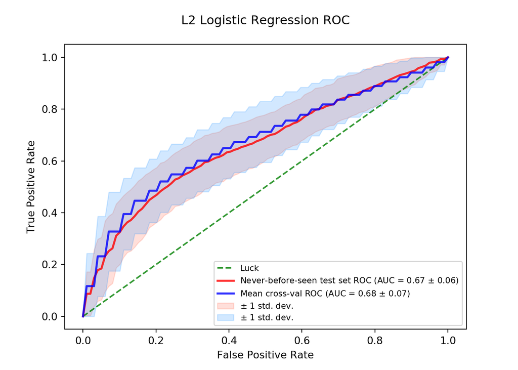

```python
plt.plot([0, 1], [0, 1], linestyle='--', color='green', label='Luck', alpha=.8)
mean_tpr_test = np.mean(tprs_test, axis=0)
mean_tpr_test[-1] = 1.0
mean_auc_test = auc(mean_fpr_test, mean_tpr_test)
std_auc_test = np.std(aucs_test)
plt.plot(mean_fpr_test, mean_tpr_test, color='r', label=r'Never-before-seen test set ROC (AUC = %0.2f $\pm$ %0.2f)' % (mean_auc_test, std_auc_test), lw=2, alpha=.8)
std_tpr_test = np.std(tprs_test, axis=0)
tprs_upper_test = np.minimum(mean_tpr_test + std_tpr_test, 1)
tprs_lower_test = np.maximum(mean_tpr_test - std_tpr_test, 0)
plt.fill_between(mean_fpr_test, tprs_lower_test, tprs_upper_test, color='tomato', alpha=.2, label=r'$\pm$ 1 std. dev.')
mean_tpr = np.mean(tprs, axis=0)
mean_tpr[-1] = 1.0
mean_auc = auc(mean_fpr, mean_tpr)
std_auc = np.std(aucs)
plt.plot(mean_fpr, mean_tpr, color='b', label=r'Mean cross-val ROC (AUC = %0.2f $\pm$ %0.2f)' % (mean_auc, std_auc), lw=2, alpha=.8)
std_tpr = np.std(tprs, axis=0)
tprs_upper = np.minimum(mean_tpr + std_tpr, 1)
tprs_lower = np.maximum(mean_tpr - std_tpr, 0)
plt.fill_between(mean_fpr, tprs_lower, tprs_upper, color='dodgerblue', alpha=.2, label=r'$\pm$ 1 std. dev.')
plt.xlim([-0.05, 1.05])
plt.ylim([-0.05, 1.05])
plt.xlabel('False Positive Rate')
plt.ylabel('True Positive Rate')
plt.title('L2 Logistic Regression ROC\n')
plt.legend(loc="lower right", fontsize=8)
plt.show()
```